# EDA 1

Este notebook analiza los comentarios realizados a publicaciones de medios argentinos en Twitter en el periodo de la pandemia, con foco en el discurso xenófobo.

**Dataset:** Aproximanadamente 5.5M comentarios a noticias de 9 medios argentinos, previamente clasificados con etiquetas binarias de odio.

**Proxy de xenofobia:** se usa la etiqueta "RACISM" como proxy de xenofobia, dado que el dataset no tiene una etiqueta específica para ese fenómeno.

**Estructura del análisis:**

1. Carga y filtro de medios argentinos
2. Distribución de noticias y comentarios por medio
3. Distribución por tipo de etiqueta
4. Llamados a la acción por etiqueta
5. Ejemplos de comentarios
6. Análisis temporal
7. Usuarios reincidentes en comentarios racistas

```python
import pandas as pd
import matplotlib.pyplot as plt
import seaborn as sns
```

## 1. Carga de datos

El dataset fue generado en `1_create_ar_dataset.ipynb`. Contiene comentarios a publicaciones de medios de comunicación. Las etiquetas de odio son binarias.

```python
file_path = 'data/tweets.csv' #Reemplazar con la ruta local del archivo CSV
tw_arg = pd.read_csv(file_path)
```

```python
tw_arg.head()
```

|  | id | tweet_id_noticia | medio | date_tweet | text | user_id | HATEFUL | CALLS | WOMEN | LGBTI | RACISM | CLASS | POLITICS | DISABLED | APPEARANCE | CRIMINAL |
| --- | --- | --- | --- | --- | --- | --- | --- | --- | --- | --- | --- | --- | --- | --- | --- | --- |
| 0 | 0 | 1376940813968609288 | clarincom | 2021-03-30 17:03:00.900 | @clarincom A mi me preocupa el trabajo.. La ev... | 1532596098 | 0 | 0 | 0 | 0 | 0 | 0 | 0 | 0 | 0 | 0 |
| 1 | 1 | 1376940813968609288 | clarincom | 2021-03-30 17:05:04.500 | @clarincom Lo que preocupa. https://t.co/Vmf9V... | 1222094021687943168 | 0 | 0 | 0 | 0 | 0 | 0 | 0 | 0 | 0 | 0 |
| 2 | 2 | 1376940813968609288 | clarincom | 2021-03-30 17:06:03.100 | @clarincom Lo que les preocupa. https://t.co/P... | 1222094021687943168 | 0 | 0 | 0 | 0 | 0 | 0 | 0 | 0 | 0 | 0 |
| 3 | 3 | 1376940813968609288 | clarincom | 2021-03-30 17:11:02.300 | @clarincom Le recomendaríamos al presidente de... | 582286194 | 0 | 0 | 0 | 0 | 0 | 0 | 0 | 0 | 0 | 0 |
| 4 | 4 | 1376940813968609288 | clarincom | 2021-03-30 17:26:00.600 | @clarincom Para salvar al correo de la quiebra... | 951552761988034560 | 0 | 0 | 0 | 0 | 0 | 0 | 0 | 0 | 0 | 0 |

```python
#Medios de comunicación presentes en el dataset
tw_arg['medio'].value_counts()
```

```
medio
infobae            1691830
LANACION           1574297
clarincom          1486018
elmundoes          1344679
abc_es              811077
latercera           595254
pagina12            221971
cronica             205588
elpaisuy            188608
perfilcom           159860
LaVanguardia        136633
laderechamedios      69944
laderechadiario      65907
izquierdadiario      17982
Name: count, dtype: int64
```

### 1.1. Filtro de medios argentinos

El dataset original incluye medios de varios países hispanohablantes. Se filtran solo los medios argentinos ya que son los relevantes para el análisis que se busca realizar.

```python
# Filtrar solo medios argentinos
medios_arg = ['LANACION', 'clarincom', 'cronica', 'infobae','izquierdadiario', 'laderechadiario', 'laderechamedios', 'pagina12', 'perfilcom']

tw_arg = tw_arg[tw_arg['medio'].isin(medios_arg)].copy()

print(f"Nuevo tamaño del dataset: {len(tw_arg):,}")
print(f"Medios incluidos: {sorted(tw_arg['medio'].unique())}")
```

```
Nuevo tamaño del dataset: 5,493,397
Medios incluidos: ['LANACION', 'clarincom', 'cronica', 'infobae', 'izquierdadiario', 'laderechadiario', 'laderechamedios', 'pagina12', 'perfilcom']
```

## 2. Distribución de noticias y comentarios por medio

### 2.1. ¿Cuántas noticias y cuántos comentarios tenemos por cada medio ?

```python
# Noticias únicas por medio (cada tweet_id_noticia es una noticia)
noticias_por_medio = (
    tw_arg.dropna(subset=['medio'])
    .groupby('medio')['tweet_id_noticia']
    .nunique()
    .sort_values(ascending=False)
    .reset_index()
    .rename(columns={'tweet_id_noticia': 'noticias'})
)

# Comentarios por medio
comentarios_por_medio = (
    tw_arg.dropna(subset=['medio'])
    .groupby('medio')
    .size()
    .sort_values(ascending=False)
    .reset_index()
    .rename(columns={0: 'comentarios'})
)

resumen = noticias_por_medio.merge(comentarios_por_medio, on='medio')
resumen
```

|  | medio | noticias | comentarios |
| --- | --- | --- | --- |
| 0 | infobae | 98751 | 1691830 |
| 1 | clarincom | 66267 | 1486018 |
| 2 | LANACION | 51536 | 1574297 |
| 3 | cronica | 50316 | 205588 |
| 4 | pagina12 | 29184 | 221971 |
| 5 | perfilcom | 21056 | 159860 |
| 6 | izquierdadiario | 7786 | 17982 |
| 7 | laderechadiario | 2904 | 65907 |
| 8 | laderechamedios | 2800 | 69944 |

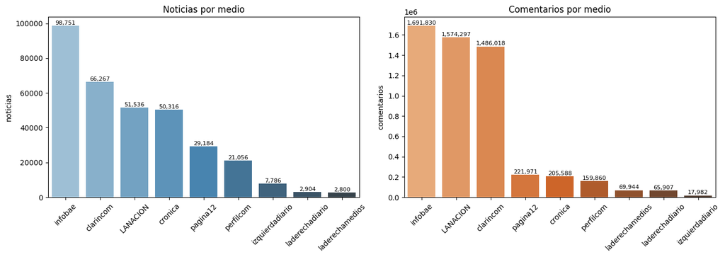

```python
#Graficos

fig, axes = plt.subplots(1, 2, figsize=(14, 5))

# Noticias por medio
resumen_sorted_n = resumen.sort_values('noticias', ascending=False)
sns.barplot(data=resumen_sorted_n, x='medio', y='noticias', hue='medio', legend=False, palette='Blues_d', ax=axes[0])
axes[0].set_title('Noticias por medio')
axes[0].set_xlabel('')
axes[0].tick_params(axis='x', rotation=45)
for bar, val in zip(axes[0].patches, resumen_sorted_n['noticias']):
    axes[0].text(bar.get_x() + bar.get_width()/2, bar.get_height() + 50,
                 f'{val:,}', ha='center', va='bottom', fontsize=8)

# Comentarios por medio
resumen_sorted_c = resumen.sort_values('comentarios', ascending=False)
sns.barplot(data=resumen_sorted_c, x='medio', y='comentarios', hue='medio', legend=False, palette='Oranges_d', ax=axes[1])
axes[1].set_title('Comentarios por medio')
axes[1].set_xlabel('')
axes[1].tick_params(axis='x', rotation=45)
for bar, val in zip(axes[1].patches, resumen_sorted_c['comentarios']):
    axes[1].text(bar.get_x() + bar.get_width()/2, bar.get_height() + 500,
                 f'{val:,}', ha='center', va='bottom', fontsize=8)

plt.tight_layout()
plt.show()
```

### 2.2. Promedio de comentarios por noticia

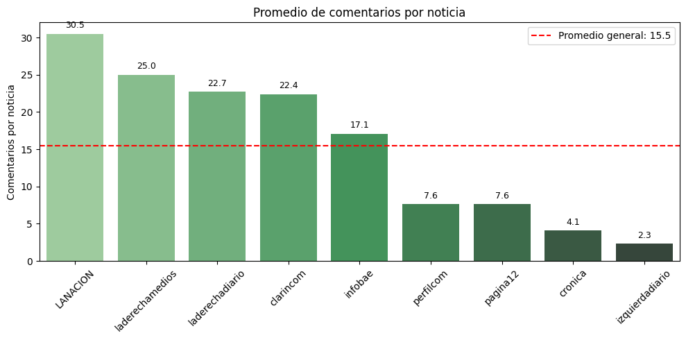

```python
ratio = resumen.copy()
ratio['comentarios_por_noticia'] = (ratio['comentarios'] / ratio['noticias']).round(1)
ratio = ratio[['medio', 'comentarios_por_noticia']].sort_values('comentarios_por_noticia', ascending=False).reset_index(drop=True)

promedio_general = ratio['comentarios_por_noticia'].mean().round(1)

fig, ax = plt.subplots(figsize=(10, 5))
sns.barplot(data=ratio, x='medio', y='comentarios_por_noticia', hue='medio', legend=False, palette='Greens_d', ax=ax)
ax.axhline(promedio_general, color='red', linestyle='--', linewidth=1.5, label=f'Promedio general: {promedio_general}')
ax.set_title('Promedio de comentarios por noticia')
ax.set_xlabel('')
ax.set_ylabel('Comentarios por noticia')
ax.tick_params(axis='x', rotation=45)
ax.legend()
for bar, val in zip(ax.patches, ratio['comentarios_por_noticia']):
    ax.text(bar.get_x() + bar.get_width()/2, bar.get_height() + 0.5,
            f'{val:,.1f}', ha='center', va='bottom', fontsize=9)

plt.tight_layout()
plt.show()
```

Podria ser interesante ver que noticia recibio mas comentarios negativos para cada medio y ver de que habla.

## 3. Distribución por tipo de etiqueta

Se contabilizan con el siguiente criterio:

- Para los comentarios: se cuentan los comentarios en los que cada etiqueta = 1
- Para las noticias: se cuenta para una etiqueta si al menos uno de sus comentarios esta etiquetado en esa categoria

### 3.1. ¿Cuántos comentarios por cada tipo de etiqueta?

```python
etiquetas = ['HATEFUL', 'CALLS', 'WOMEN', 'LGBTI', 'RACISM', 'CLASS', 'POLITICS', 'DISABLED', 'APPEARANCE', 'CRIMINAL']

# Comentarios por etiqueta
comentarios_por_etiqueta = tw_arg[etiquetas].sum().sort_values(ascending=False).reset_index()
comentarios_por_etiqueta.columns = ['etiqueta', 'comentarios']

print("Comentarios por etiqueta:")
print(comentarios_por_etiqueta.to_string(index=False))
```

```
Comentarios por etiqueta:
  etiqueta  comentarios
   HATEFUL       340593
APPEARANCE       106462
  POLITICS        93515
  DISABLED        44025
     WOMEN        43742
  CRIMINAL        37583
    RACISM        35872
     CLASS        24033
     CALLS        21640
     LGBTI        16883
```

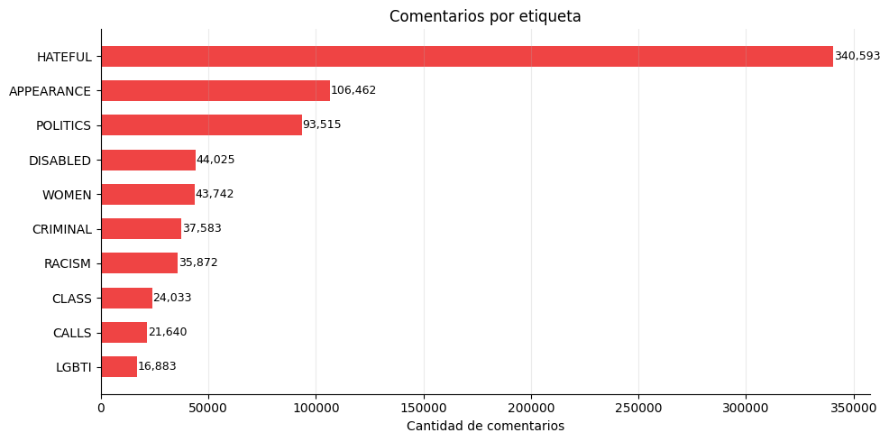

```python
#Grafico de comentarios por etiqueta
sorted_c = comentarios_por_etiqueta.sort_values('comentarios', ascending=True)

fig, ax = plt.subplots(figsize=(10, 5))
ax.barh(sorted_c['etiqueta'], sorted_c['comentarios'], color='#ef4444', height=0.6)
for i, (_, row) in enumerate(sorted_c.iterrows()):
    ax.text(row['comentarios'] + 200, i, f"{int(row['comentarios']):,}", va='center', fontsize=9)

ax.set_title('Comentarios por etiqueta')
ax.set_xlabel('Cantidad de comentarios')
ax.grid(axis='x', alpha=0.25)
sns.despine()
plt.tight_layout()
plt.show()
```

### 3.2. ¿Cuántas noticias por etiqueta?

```python
# Noticias por etiqueta (al menos un comentario con etiqueta = 1 en esa categoria)
noticias_por_etiqueta = (
    tw_arg.groupby('tweet_id_noticia')[etiquetas]
    .max()
    .sum()
    .sort_values(ascending=False)
    .reset_index()
)
noticias_por_etiqueta.columns = ['etiqueta', 'noticias']

print("\nNoticias por etiqueta:")
print(noticias_por_etiqueta.to_string(index=False))
```

```
Noticias por etiqueta:
  etiqueta  noticias
   HATEFUL     81515
  POLITICS     36812
APPEARANCE     30719
    RACISM     17692
     WOMEN     16983
  DISABLED     16777
     CLASS     10815
     CALLS     10276
  CRIMINAL      8322
     LGBTI      7954
```

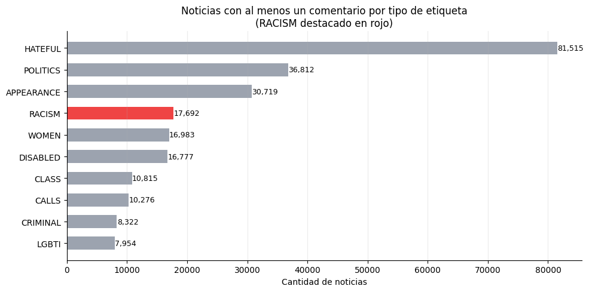

```python
# Grafico de noticias por etiqueta (al menos un comentario con esa etiqueta)
sorted_n = noticias_por_etiqueta.sort_values('noticias', ascending=True).reset_index(drop=True)
bar_colors = ['#ef4444' if e == 'RACISM' else '#9ca3af' for e in sorted_n['etiqueta']]

fig, ax = plt.subplots(figsize=(10, 5))
ax.barh(sorted_n['etiqueta'], sorted_n['noticias'], color=bar_colors, height=0.6)
for i, (_, row) in enumerate(sorted_n.iterrows()):
    ax.text(row['noticias'] + 50, i, f"{int(row['noticias']):,}", va='center', fontsize=9)

ax.set_title('Noticias con al menos un comentario por tipo de etiqueta\n(RACISM destacado en rojo)', fontsize=12)
ax.set_xlabel('Cantidad de noticias')
ax.grid(axis='x', alpha=0.25)
sns.despine()
plt.tight_layout()
plt.show()
```

## 4. Llamados a la acción por etiqueta

La columna CALLS indica que el comentario contiene un llamado explícito a hacer algo (denunciar, expulsar, agredir, etc.). Se analiza qué proporción de los comentarios de cada categoría de odio incluyen además un llamado a la acción, y cuáles son los subtipos más frecuentes dentro de los comentarios con `CALLS = 1`.

### 4.1. Llamados por etiqueta

```python
calls_df = tw_arg[tw_arg['CALLS'] == 1]

# Excluimos CALLS para no cruzarla consigo misma
etiquetas_odio = [e for e in etiquetas if e != 'CALLS']

resultado = []
for etiqueta in etiquetas_odio:
    total = tw_arg[etiqueta].sum()
    calls = calls_df[etiqueta].sum()
    porcentaje = calls / total * 100 if total > 0 else 0
    resultado.append({'etiqueta': etiqueta, 'total': total, 'llamados a la accion': calls, '% llamados': round(porcentaje, 1)})

calls_por_etiqueta = pd.DataFrame(resultado).sort_values('llamados a la accion', ascending=False).reset_index(drop=True)
calls_por_etiqueta
```

|  | etiqueta | total | llamados a la accion | % llamados |
| --- | --- | --- | --- | --- |
| 0 | HATEFUL | 340593 | 21640 | 6.4 |
| 1 | CRIMINAL | 37583 | 11865 | 31.6 |
| 2 | RACISM | 35872 | 5541 | 15.4 |
| 3 | POLITICS | 93515 | 4175 | 4.5 |
| 4 | CLASS | 24033 | 2509 | 10.4 |
| 5 | APPEARANCE | 106462 | 650 | 0.6 |
| 6 | WOMEN | 43742 | 445 | 1.0 |
| 7 | LGBTI | 16883 | 178 | 1.1 |
| 8 | DISABLED | 44025 | 177 | 0.4 |

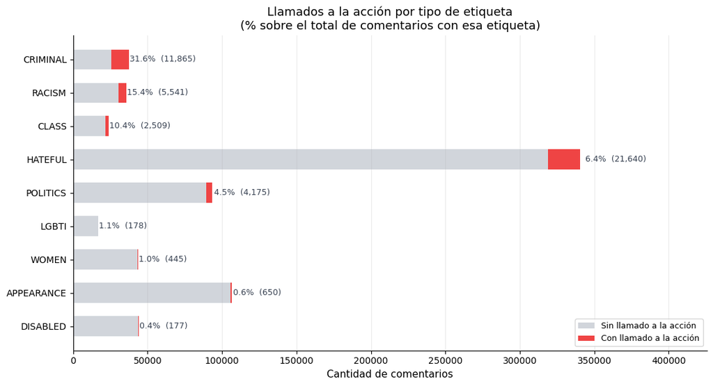

```python
# Grafico de llamados a la acción por etiqueta
sorted_pct = calls_por_etiqueta.sort_values('% llamados', ascending=True).reset_index(drop=True)

sin_calls = sorted_pct['total'] - sorted_pct['llamados a la accion']
con_calls = sorted_pct['llamados a la accion']

fig, ax = plt.subplots(figsize=(11, 6))

bars_sin = ax.barh(sorted_pct['etiqueta'], sin_calls, color='#d1d5db', label='Sin llamado a la acción', height=0.6)
bars_con = ax.barh(sorted_pct['etiqueta'], con_calls, left=sin_calls, color='#ef4444', label='Con llamado a la acción', height=0.6)

# Etiqueta de porcentaje al final de la barra roja
for i, (_, row) in enumerate(sorted_pct.iterrows()):
    total = row['total']
    calls = int(row['llamados a la accion'])
    pct = row['% llamados']
    ax.text(
        total + total * 0.01, i,
        f'{pct}%  ({calls:,})',
        va='center', ha='left', fontsize=9, color='#374151'
    )

ax.set_xlim(0, sorted_pct['total'].max() * 1.25)
ax.set_xlabel('Cantidad de comentarios', fontsize=11)
ax.set_title('Llamados a la acción por tipo de etiqueta\n(% sobre el total de comentarios con esa etiqueta)', fontsize=13)
ax.legend(loc='lower right', fontsize=9)
ax.grid(axis='x', alpha=0.25)
sns.despine()

plt.tight_layout()
plt.show()
```

### 4.2. Etiquetas por llamados

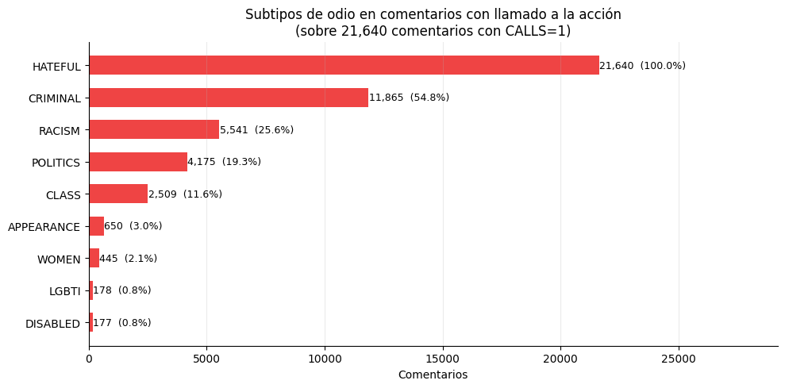

```
De los 21,640 comentarios de odio con llamado a la acción, 5,541 (25.6%) son racistas.
```

```python
# Distribución de subtipos de odio dentro de los comentarios con llamado a la acción
calls_df = tw_arg[tw_arg['CALLS'] == 1]
subtipos = [e for e in etiquetas if e != 'CALLS']
conteos = calls_df[subtipos].sum().sort_values(ascending=True)
total_calls = len(calls_df)

fig, ax = plt.subplots(figsize=(10, 5))
ax.barh(conteos.index, conteos.values, color='#ef4444', height=0.6)
for i, (subtipo, val) in enumerate(conteos.items()):
    pct = val / total_calls * 100
    ax.text(val + 10, i, f"{int(val):,}  ({pct:.1f}%)", va='center', fontsize=9)

ax.set_xlim(0, conteos.max() * 1.35)
ax.set_title(f'Subtipos de odio en comentarios con llamado a la acción\n(sobre {total_calls:,} comentarios con CALLS=1)', fontsize=12)
ax.set_xlabel('Comentarios')
ax.grid(axis='x', alpha=0.25)
sns.despine()
plt.tight_layout()
plt.show()

# Stat: qué proporción de los comentarios de odio+llamado son además racistas
hate_calls = tw_arg[(tw_arg['HATEFUL'] == 1) & (tw_arg['CALLS'] == 1)]
hate_calls_racist = hate_calls[hate_calls['RACISM'] == 1]
pct_racist = len(hate_calls_racist) / len(hate_calls) * 100
print(f"De los {len(hate_calls):,} comentarios de odio con llamado a la acción, "
      f"{len(hate_calls_racist):,} ({pct_racist:.1f}%) son racistas.")
```

## 5. Ejemplos de comentarios racistas

Muestra de comentarios clasificados con `RACISM = 1`, tanto sin llamado a la acción como con `CALLS = 1`.

```python
#Ejemplos de comentarios racistas
racist_tweets = tw_arg[tw_arg['RACISM'] == 1]['text'].head(5)
print("Ejemplos de tweets racistas:")
for tweet in racist_tweets:
    print(tweet)

#Ejemplos de comentarios racistas con llamadas a la acción
racist_calls = tw_arg[(tw_arg['RACISM'] == 1) & (tw_arg['CALLS'] == 1)]
print("\nEjemplos de tweets racistas con llamadas a la acción:")
for tweet in racist_calls['text'].head(5):
    print(tweet)
```

```
Ejemplos de tweets racistas:
@cronica ojalá vengan y nos invadan !!! y esta vez nada de resistirse!!!!
@clarincom No tuvieron los huevos suficientes para reclamarle a China por éste virus de mierda.
@laderechadiario Que le pasa a esta cojuda?
@LANACION Los chinos comunistas de mierda mataron a tu madre. No vos.
@LANACION No aman su país que se queden afuera no tenemos x que aguantar que nos traigan más peste basta y grandes multas como hace Inglaterra

Ejemplos de tweets racistas con llamadas a la acción:
@cronica ojalá vengan y nos invadan !!! y esta vez nada de resistirse!!!!
@cronica Como se hace en medio Oriente  se los hace arrodillar  y con una GLOK, en la  cabeza y listo ya es hora de acabar a estos negros de mierda,  negros de mierda ok
@LANACION CIERREN LAS ESCUELAS, NO REPATRIEN A NADIE. LA CEPA DE MANAOS CONTAGIA Y MATA A GENTE DE TODA EDAD. BRASIL 4000 MUERTES DIARIAS.
@LANACION Yo propongo un plebiscito nacional para definir si echarlos, o pedirle a Chile que los anexione.
@LANACION Migración masiva a Mendoza!
```

## 6. Análisis temporal

Se analiza la evolución en el tiempo de los comentarios de odio y racistas. El objetivo es ver picos puntuales;

- Nota: `laderechamedios` solo tiene datos entre jul 2020 y feb 2021 , por lo que su línea aparece truncada en los gráficos

### 6.1. Serie temporal de comentarios de odio por dia

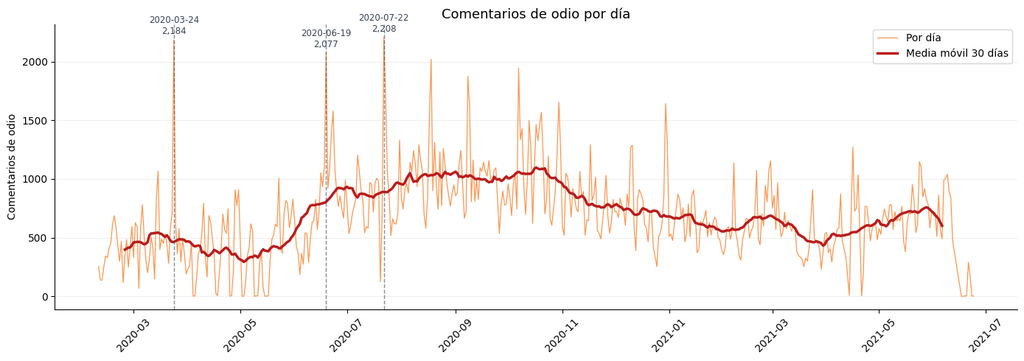

```python
#Evolución temporal de los comentarios de odio por día
tw_arg['date_only'] = tw_arg['date_tweet'].dt.date
hate_daily_counts = tw_arg[tw_arg['HATEFUL'] == 1].groupby('date_only').size().reset_index(name='hate_tweet_count')
hate_daily_counts['rolling_30'] = hate_daily_counts['hate_tweet_count'].rolling(30, center=True).mean()
hate_daily_counts['date_dt'] = pd.to_datetime(hate_daily_counts['date_only'])

top_picos = hate_daily_counts.nlargest(3, 'hate_tweet_count')

fig, ax = plt.subplots(figsize=(14, 5))
ax.plot(hate_daily_counts['date_dt'], hate_daily_counts['hate_tweet_count'],
        color='#f97316', linewidth=0.9, alpha=0.75, label='Por día')
ax.plot(hate_daily_counts['date_dt'], hate_daily_counts['rolling_30'],
        color='#b91c1c', linewidth=2.5, label='Media móvil 30 días')

for _, row in top_picos.iterrows():
    ax.axvline(row['date_dt'], color='#374151', linewidth=1, linestyle='--', alpha=0.6)
    ax.text(row['date_dt'], row['hate_tweet_count'] + 30,
            f"{row['date_only']}\n{int(row['hate_tweet_count']):,}",
            ha='center', va='bottom', fontsize=8.5, color='#374151')

ax.set_title('Comentarios de odio por día', fontsize=13)
ax.set_ylabel('Comentarios de odio')
ax.tick_params(axis='x', rotation=45)
ax.legend(fontsize=10)
ax.grid(axis='y', alpha=0.2)
sns.despine()
plt.tight_layout()
plt.show()
```

#### 6.2. Serie temporal de comentarios racistas por dia

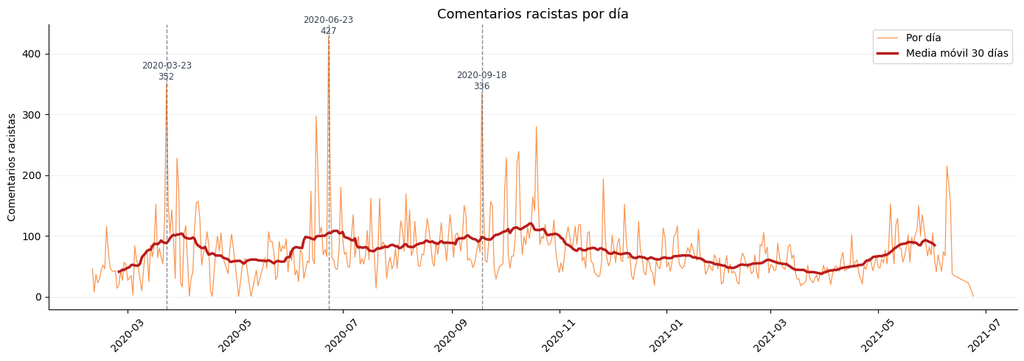

```python
#Evolución temporal de los comentarios racistas por día
tw_arg['date_only'] = tw_arg['date_tweet'].dt.date
racism_daily = tw_arg[tw_arg['RACISM'] == 1].groupby('date_only').size().reset_index(name='count')
racism_daily['rolling_30'] = racism_daily['count'].rolling(30, center=True).mean()
racism_daily['date_dt'] = pd.to_datetime(racism_daily['date_only'])

top_picos = racism_daily.nlargest(3, 'count')

fig, ax = plt.subplots(figsize=(14, 5))
ax.plot(racism_daily['date_dt'], racism_daily['count'],
        color='#f97316', linewidth=0.9, alpha=0.75, label='Por día')
ax.plot(racism_daily['date_dt'], racism_daily['rolling_30'],
        color='#b91c1c', linewidth=2.5, label='Media móvil 30 días')

for _, row in top_picos.iterrows():
    ax.axvline(row['date_dt'], color='#374151', linewidth=1, linestyle='--', alpha=0.6)
    ax.text(row['date_dt'], row['count'] + 2,
            f"{row['date_only']}\n{int(row['count']):,}",
            ha='center', va='bottom', fontsize=8.5, color='#374151')

ax.set_title('Comentarios racistas por día', fontsize=13)
ax.set_ylabel('Comentarios racistas')
ax.tick_params(axis='x', rotation=45)
ax.legend(fontsize=10)
ax.grid(axis='y', alpha=0.2)
sns.despine()
plt.tight_layout()
plt.show()
```

Observación: Las fechas de los picos en los graficos son diferentes:

- Para los comentarios de odio los picos son el 24 de marzo, 19 de junio y el 22 de julio de 2020
- Para los comentarios racistas los picos son el 23 de marzo, el 23 de junio y el 18 de septiembre de 2020

Estaria bueno cruzar ver las noticias de estas fechas aparte para analizar el contenido de los comentarios

#### 6.3. Serie temporal de comentarios racistas y totales

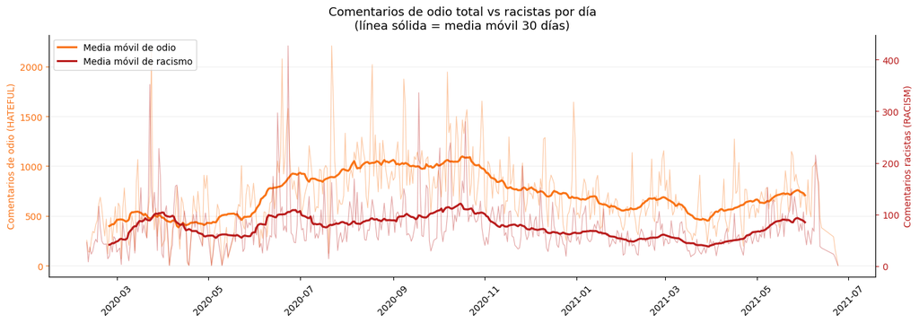

```python
# Comentarios racistas vs comentarios de odio totales por día (doble eje Y) con media móvil 30 días
tw_arg['date_only'] = tw_arg['date_tweet'].dt.date

hate_daily   = tw_arg[tw_arg['HATEFUL'] == 1].groupby('date_only').size().reset_index(name='hate')
racism_daily = tw_arg[tw_arg['RACISM']  == 1].groupby('date_only').size().reset_index(name='racism')

daily = hate_daily.merge(racism_daily, on='date_only')
daily['date_dt']      = pd.to_datetime(daily['date_only'])
daily['roll_hate']    = daily['hate'].rolling(30, center=True).mean()
daily['roll_racism']  = daily['racism'].rolling(30, center=True).mean()

fig, ax1 = plt.subplots(figsize=(14, 5))
ax2 = ax1.twinx()

ax1.plot(daily['date_dt'], daily['hate'],       color='#f97316', linewidth=0.8, alpha=0.4)
ax1.plot(daily['date_dt'], daily['roll_hate'],  color='#f97316', linewidth=2.2, label='Media móvil de odio')

ax2.plot(daily['date_dt'], daily['racism'],      color='#b91c1c', linewidth=0.8, alpha=0.4)
ax2.plot(daily['date_dt'], daily['roll_racism'], color='#b91c1c', linewidth=2.2, label='Media móvil de racismo')

ax1.set_ylabel('Comentarios de odio (HATEFUL)', color='#f97316', fontsize=10)
ax2.set_ylabel('Comentarios racistas (RACISM)',  color='#b91c1c', fontsize=10)
ax1.tick_params(axis='y', colors='#f97316')
ax2.tick_params(axis='y', colors='#b91c1c')
ax1.tick_params(axis='x', rotation=45)

lines1, labels1 = ax1.get_legend_handles_labels()
lines2, labels2 = ax2.get_legend_handles_labels()
ax1.legend(lines1 + lines2, labels1 + labels2, fontsize=10, loc='upper left')

ax1.set_title('Comentarios de odio total vs racistas por día\n(línea sólida = media móvil 30 días)', fontsize=13)
ax1.grid(axis='y', alpha=0.2)
sns.despine(right=False)
plt.tight_layout()
plt.show()
```

Aclaración: El gráfico usa doble eje Y: el eje izquierdo (naranja) corresponde a comentarios de odio total (HATEFUL) y el eje derecho (rojo) a comentarios racistas (RACISM). Las escalas son distintas por lo que la proximidad visual de las líneas no implica magnitudes similares, solo sirve para ver si se mueven de manera similar

### 6.4. Serie temporal de comentarios racistas por medio

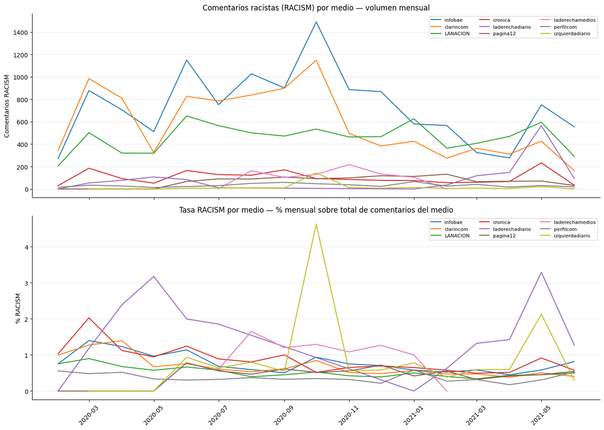

```python
tw_arg['date_tweet'] = pd.to_datetime(tw_arg['date_tweet'])
tw_arg['mes'] = tw_arg['date_tweet'].dt.to_period('M')

# Por medio por mes
total_por_medio_mes   = tw_arg.groupby(['medio', 'mes']).size().reset_index(name='total')
racism_por_medio_mes  = tw_arg[tw_arg['RACISM']  == 1].groupby(['medio', 'mes']).size().reset_index(name='racism')
hateful_por_medio_mes = tw_arg[tw_arg['HATEFUL'] == 1].groupby(['medio', 'mes']).size().reset_index(name='hateful')

df_ts = (total_por_medio_mes
         .merge(racism_por_medio_mes,  on=['medio', 'mes'], how='left')
         .merge(hateful_por_medio_mes, on=['medio', 'mes'], how='left')
         .fillna(0))
df_ts['tasa_racism']  = df_ts['racism']  / df_ts['total'] * 100
df_ts['tasa_hateful'] = df_ts['hateful'] / df_ts['total'] * 100
df_ts['fecha'] = df_ts['mes'].dt.to_timestamp()

# Orden de medios por volumen total de RACISM
orden_medios = (
    df_ts.groupby('medio')['racism'].sum()
    .sort_values(ascending=False)
    .index.tolist()
)

palette   = sns.color_palette('tab10', n_colors=len(orden_medios))
color_map = dict(zip(orden_medios, palette))

# Gráfico 1: RACISM
fig, axes = plt.subplots(2, 1, figsize=(14, 10), sharex=True)

for medio in orden_medios:
    d = df_ts[df_ts['medio'] == medio]
    axes[0].plot(d['fecha'], d['racism'], label=medio, color=color_map[medio], linewidth=1.5)
axes[0].set_title('Comentarios racistas (RACISM) por medio — volumen mensual', fontsize=12)
axes[0].set_ylabel('Comentarios RACISM')
axes[0].legend(fontsize=8, ncol=3, loc='upper right')
axes[0].grid(axis='y', alpha=0.25)
sns.despine(ax=axes[0])

for medio in orden_medios:
    d = df_ts[df_ts['medio'] == medio]
    axes[1].plot(d['fecha'], d['tasa_racism'], label=medio, color=color_map[medio], linewidth=1.5)
axes[1].set_title('Tasa RACISM por medio — % mensual sobre total de comentarios del medio', fontsize=12)
axes[1].set_ylabel('% RACISM')
axes[1].legend(fontsize=8, ncol=3, loc='upper right')
axes[1].tick_params(axis='x', rotation=45)
axes[1].grid(axis='y', alpha=0.25)
sns.despine(ax=axes[1])

plt.tight_layout()
plt.show()
```

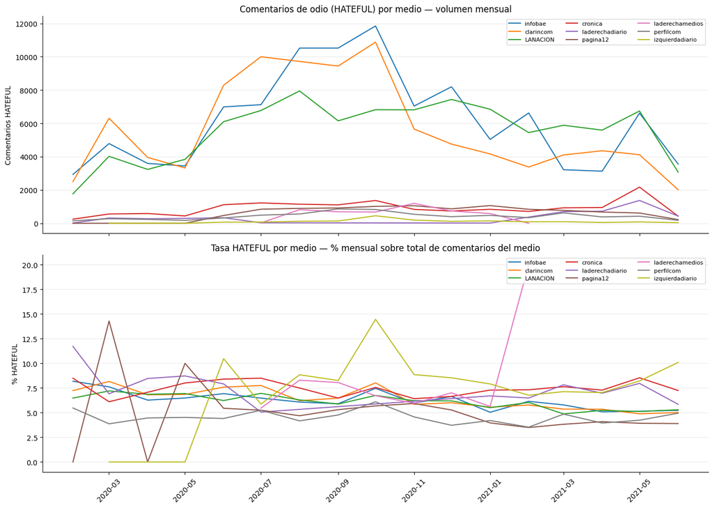

```python
# Gráfico 2: HATEFUL
fig, axes = plt.subplots(2, 1, figsize=(14, 10), sharex=True)

for medio in orden_medios:
    d = df_ts[df_ts['medio'] == medio]
    axes[0].plot(d['fecha'], d['hateful'], label=medio, color=color_map[medio], linewidth=1.5)
axes[0].set_title('Comentarios de odio (HATEFUL) por medio — volumen mensual', fontsize=12)
axes[0].set_ylabel('Comentarios HATEFUL')
axes[0].legend(fontsize=8, ncol=3, loc='upper right')
axes[0].grid(axis='y', alpha=0.25)
sns.despine(ax=axes[0])

for medio in orden_medios:
    d = df_ts[df_ts['medio'] == medio]
    axes[1].plot(d['fecha'], d['tasa_hateful'], label=medio, color=color_map[medio], linewidth=1.5)
axes[1].set_title('Tasa HATEFUL por medio — % mensual sobre total de comentarios del medio', fontsize=12)
axes[1].set_ylabel('% HATEFUL')
axes[1].legend(fontsize=8, ncol=3, loc='upper right')
axes[1].tick_params(axis='x', rotation=45)
axes[1].grid(axis='y', alpha=0.25)
sns.despine(ax=axes[1])

plt.tight_layout()
plt.show()
```

## 7. Usuarios reincidentes en comentarios racistas

Se identifican los usuarios que realizaron más de un comentario con `RACISM = 1`. Luego se analizan los comentarios realizados y un perfil del usuiario con todas las etiquetas para ver si el odio es particularmente racista o si tambien ejercen otros tipos de odio

### 7.1. Usuarios racistas

```python
#Separo solo los comentarios racistas para analizar la distribución por usuario
df_racist = tw_arg[tw_arg['RACISM'] == 1].copy()

comentarios_por_usuario = df_racist.groupby('user_id').size().reset_index(name='n_comentarios')


total_usuarios  = len(comentarios_por_usuario)
usuarios_1      = (comentarios_por_usuario['n_comentarios'] == 1).sum()
usuarios_2_5    = comentarios_por_usuario['n_comentarios'].between(2, 5).sum()
usuarios_6_plus = (comentarios_por_usuario['n_comentarios'] > 5).sum()

print(f"Comentarios racistas totales : {len(df_racist):}")
print(f"Usuarios únicos              : {total_usuarios:}")
print(f"  — Usuarios con 1 comentario            : {usuarios_1:}  ({usuarios_1/total_usuarios*100:.1f}%)")
print(f"  — Usuarios con 2 a 5 comentarios        : {usuarios_2_5:}  ({usuarios_2_5/total_usuarios*100:.1f}%)")
print(f"  — Usuarios con más de 5 comentarios     : {usuarios_6_plus:}  ({usuarios_6_plus/total_usuarios*100:.1f}%)")
print()

# Comentarios generados por reincidentes
comentarios_reincidentes = (comentarios_por_usuario[comentarios_por_usuario['n_comentarios'] > 1]).sum()['n_comentarios']
print(f"Comentarios generados por usuarios con más de 1 tweet racista: "
      f"{comentarios_reincidentes:} ({comentarios_reincidentes/len(df_racist)*100:.1f}% del total)")
```

```
Comentarios racistas totales : 35872
Usuarios únicos              : 20047
  — Usuarios con 1 comentario            : 14397  (71.8%)
  — Usuarios con 2 a 5 comentarios        : 4877  (24.3%)
  — Usuarios con más de 5 comentarios     : 773  (3.9%)

Comentarios generados por usuarios con más de 1 tweet racista: 21475 (59.9% del total)
```

### 7.2. Usuarios racistas reincidentes

```python
# Top reincidentes: resumen por usuario
top_reincidentes = (
    comentarios_por_usuario
    .nlargest(10, 'n_comentarios')
    .merge(
        df_racist.groupby('user_id').agg(
            n_noticias=('tweet_id_noticia', 'nunique'),
            n_medios=('medio', 'nunique'),
            medios=('medio', lambda x: ', '.join(sorted(x.unique())))
        ).reset_index(),
        on='user_id'
    )
)
print("Top 10 usuarios con más comentarios racistas:")
print(top_reincidentes[['user_id','n_comentarios','n_noticias','n_medios','medios']].to_string(index=False))
```

```
Top 10 usuarios con más comentarios racistas:
            user_id  n_comentarios  n_noticias  n_medios                                            medios
         4819881863             97          97         5 LANACION, clarincom, infobae, pagina12, perfilcom
1304054864465530881             84          83         4           LANACION, clarincom, infobae, perfilcom
         4234373379             62          62         3                      LANACION, clarincom, infobae
1217504583947296769             61          61         5   LANACION, clarincom, cronica, infobae, pagina12
1184956448784211968             58          58         4             LANACION, clarincom, cronica, infobae
1191123861556940801             58          58         4            LANACION, clarincom, cronica, pagina12
         1532596098             52          50         4           LANACION, clarincom, infobae, perfilcom
 735477312083238912             52          52         2                                clarincom, cronica
 990352152563417088             52          52         3                      LANACION, clarincom, infobae
         2324055729             51          51         3                      LANACION, infobae, perfilcom
```

```python
# Comentarios reales de cada usuario del top 10
for _, row in top_reincidentes.iterrows():
    uid = row['user_id']
    tweets = df_racist[df_racist['user_id'] == uid]['text'].tolist()
    print(f"── user_id: {uid}  ({len(tweets)} comentarios) ──────────────────")
    for t in tweets:
        print(f"  {t}")
    print()
```

[output not shown]

### 7.3. Perfil completo de los usuarios del top 10

Para cada usuario del top 10 se toman todos sus comentarios en el dataset (no solo los racistas) y se calcula cuántos tienen en cada etiqueta. Se busca ver si son usuarios con un patrón específico de racismo o si tambien presentan otros tipos de odio.

```python
# Perfil completo en el dataset de los usuarios del top 10

top_ids = top_reincidentes['user_id'].tolist()
todos = tw_arg[tw_arg['user_id'].isin(top_ids)]

perfil = (
    todos.groupby('user_id')
    .agg(total_comentarios=('id', 'count'), **{e: (e, 'sum') for e in etiquetas})
    .reset_index()
)

# Calcular % de cada etiqueta sobre el total de comentarios del usuario
for e in etiquetas:
    perfil[f'%_{e}'] = (perfil[e] / perfil['total_comentarios'] * 100).round(1)

perfil = perfil.merge(top_reincidentes[['user_id', 'n_comentarios']], on='user_id')
perfil = perfil.rename(columns={'n_comentarios': 'racism_count'}).sort_values('racism_count', ascending=False)

# Tabla de conteos absolutos
print("Conteos absolutos por etiqueta (todos los comentarios del usuario en el dataset):")
cols_abs = ['user_id', 'total_comentarios'] + etiquetas
print(perfil[cols_abs].to_string(index=False))

print()

# Tabla de porcentajes
print("Porcentaje de comentarios con cada etiqueta:")
cols_pct = ['user_id', 'total_comentarios'] + [f'%_{e}' for e in etiquetas]
print(perfil[cols_pct].to_string(index=False))
```

```
Conteos absolutos por etiqueta (todos los comentarios del usuario en el dataset):
            user_id  total_comentarios  HATEFUL  CALLS  WOMEN  LGBTI  RACISM  CLASS  POLITICS  DISABLED  APPEARANCE  CRIMINAL
         4819881863               1159      166      1      5      3      97     22       109        24          17         1
1304054864465530881                306      115      0      7      2      84      4        16         5           6         0
         4234373379               1851      413      7     69     50      62     11       117        68         115        22
1217504583947296769               3500      242     23     29     18      61     45        34        32          50        21
1191123861556940801               1106      194      7      0      4      58      7       123         2          31         3
1184956448784211968                848      168      8     18      8      58     27        49        22          44        17
 990352152563417088               2878      723     16      9     11      52     71       590         9          58        43
         1532596098               2615      217     36     25      6      52     30        27        16          25        66
 735477312083238912               2187      214      7     37      3      52      1        75        30          32         9
         2324055729                733       98     15     13      2      51     24        13         3          13        24

Porcentaje de comentarios con cada etiqueta:
            user_id  total_comentarios  %_HATEFUL  %_CALLS  %_WOMEN  %_LGBTI  %_RACISM  %_CLASS  %_POLITICS  %_DISABLED  %_APPEARANCE  %_CRIMINAL
         4819881863               1159       14.3      0.1      0.4      0.3       8.4      1.9         9.4         2.1           1.5         0.1
1304054864465530881                306       37.6      0.0      2.3      0.7      27.5      1.3         5.2         1.6           2.0         0.0
         4234373379               1851       22.3      0.4      3.7      2.7       3.3      0.6         6.3         3.7           6.2         1.2
1217504583947296769               3500        6.9      0.7      0.8      0.5       1.7      1.3         1.0         0.9           1.4         0.6
1191123861556940801               1106       17.5      0.6      0.0      0.4       5.2      0.6        11.1         0.2           2.8         0.3
1184956448784211968                848       19.8      0.9      2.1      0.9       6.8      3.2         5.8         2.6           5.2         2.0
 990352152563417088               2878       25.1      0.6      0.3      0.4       1.8      2.5        20.5         0.3           2.0         1.5
         1532596098               2615        8.3      1.4      1.0      0.2       2.0      1.1         1.0         0.6           1.0         2.5
 735477312083238912               2187        9.8      0.3      1.7      0.1       2.4      0.0         3.4         1.4           1.5         0.4
         2324055729                733       13.4      2.0      1.8      0.3       7.0      3.3         1.8         0.4           1.8         3.3
```

Puede que en el contexto de los comentarios peruka hable de algo mas politico relacionado al peronismo y no necesariamente de un ataque a personas de nacionalidad peruana. Esta observacion es viendo el caso del usuario 4819881863 que si se leen los comentarios que hizo se ve un uso abusivo de la palabra "peruka" pero viendo el perfil completo tambien tiende a atacar en relación a la política.